# Model_jh4054

```r
##########
# 7 predictor adjusted R2 model
# Adjusted R-squared:  0.4927
fit_r2 = lm(target_death_rate ~ incidence_rate + median_age_male + pct_hs18_24 + pct_bach_deg25_over + pct_public_coverage_alone + pct_other_race + pct_married_households, data = cancer_reg_tidy)

summary(fit_r2)
```

```
##
## Call:
## lm(formula = target_death_rate ~ incidence_rate + median_age_male +
##     pct_hs18_24 + pct_bach_deg25_over + pct_public_coverage_alone +
##     pct_other_race + pct_married_households, data = cancer_reg_tidy)
##
## Residuals:
##      Min       1Q   Median       3Q      Max
## -102.952  -11.206   -0.349   11.378  139.955
##
## Coefficients:
##                             Estimate Std. Error t value Pr(>|t|)
## (Intercept)               134.862351   6.689670  20.160  < 2e-16 ***
## incidence_rate              0.193329   0.006817  28.360  < 2e-16 ***
## median_age_male            -0.505309   0.075069  -6.731 2.00e-11 ***
## pct_hs18_24                 0.350494   0.044741   7.834 6.49e-15 ***
## pct_bach_deg25_over        -1.634633   0.091003 -17.962  < 2e-16 ***
## pct_public_coverage_alone   0.766636   0.087910   8.721  < 2e-16 ***
## pct_other_race             -1.057351   0.109426  -9.663  < 2e-16 ***
## pct_married_households     -0.508859   0.067856  -7.499 8.38e-14 ***
## ---
## Signif. codes:  0 '***' 0.001 '**' 0.01 '*' 0.05 '.' 0.1 ' ' 1
##
## Residual standard error: 19.77 on 3039 degrees of freedom
## Multiple R-squared:  0.4939, Adjusted R-squared:  0.4927
## F-statistic: 423.6 on 7 and 3039 DF,  p-value: < 2.2e-16
```

```r
car::vif(fit_r2) # VIF values
```

```
##            incidence_rate           median_age_male
##                  1.078569                  1.199957
##               pct_hs18_24       pct_bach_deg25_over
##                  1.283805                  1.879120
## pct_public_coverage_alone            pct_other_race
##                  2.251607                  1.155218
##    pct_married_households
##                  1.550888
```

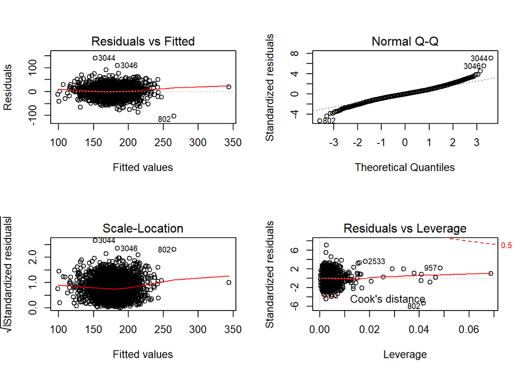

```r
# Diagnostic plots
par(mfrow = c(2,2))
plot(fit_r2)
```

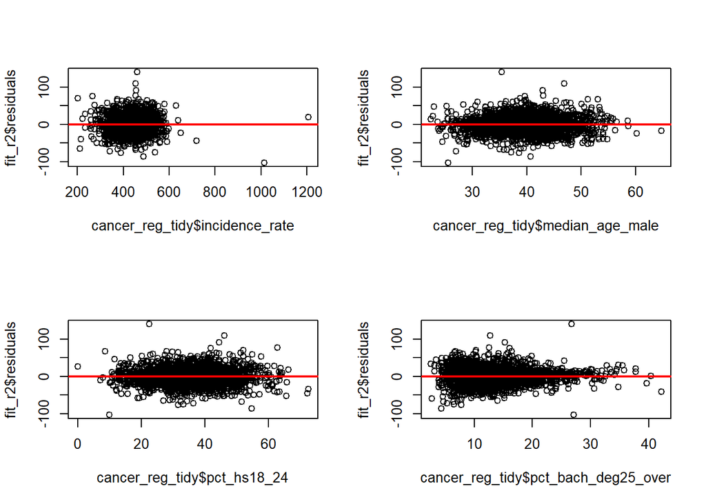

```r
#residual covariate plot
plot(cancer_reg_tidy$incidence_rate, fit_r2$residuals)
abline(h=0, lwd=2, col=2)
plot(cancer_reg_tidy$median_age_male, fit_r2$residuals)
abline(h=0, lwd=2, col=2)
plot(cancer_reg_tidy$pct_hs18_24, fit_r2$residuals)
abline(h=0, lwd=2, col=2)
plot(cancer_reg_tidy$pct_bach_deg25_over, fit_r2$residuals)
abline(h=0, lwd=2, col=2)
```

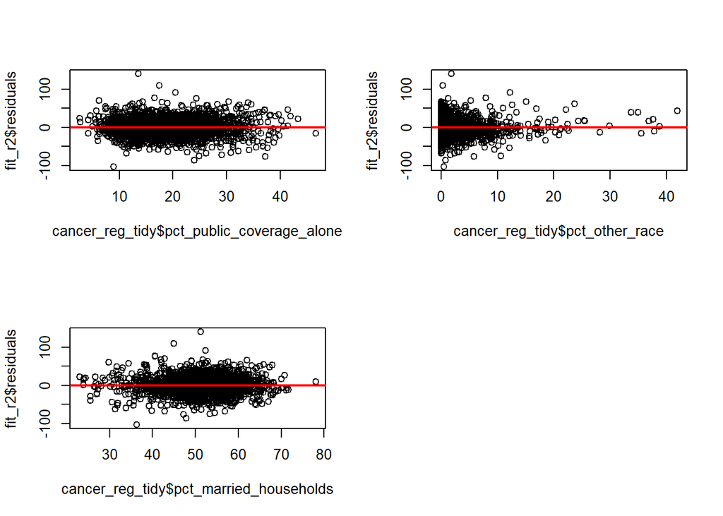

```r
plot(cancer_reg_tidy$pct_public_coverage_alone, fit_r2$residuals)
abline(h=0, lwd=2, col=2)
plot(cancer_reg_tidy$pct_other_race, fit_r2$residuals)
abline(h=0, lwd=2, col=2)
plot(cancer_reg_tidy$pct_married_households, fit_r2$residuals)
abline(h=0, lwd=2, col=2)
```

### 6. Remove one outlier in y

```r
cancer_reg_remove =
  cancer_reg_tidy %>%
  filter(target_death_rate < 300)

model_remove = lm(formula = target_death_rate ~ incidence_rate + median_age_male + pct_hs18_24 + pct_bach_deg25_over + pct_public_coverage_alone + pct_other_race + pct_married_households, data = cancer_reg_remove)

summary(model_remove)
```

```
##
## Call:
## lm(formula = target_death_rate ~ incidence_rate + median_age_male +
##     pct_hs18_24 + pct_bach_deg25_over + pct_public_coverage_alone +
##     pct_other_race + pct_married_households, data = cancer_reg_remove)
##
## Residuals:
##      Min       1Q   Median       3Q      Max
## -101.990  -11.194   -0.291   11.284  139.960
##
## Coefficients:
##                            Estimate Std. Error t value Pr(>|t|)
## (Intercept)               135.82556    6.75929  20.095  < 2e-16 ***
## incidence_rate              0.19150    0.00706  27.127  < 2e-16 ***
## median_age_male            -0.50663    0.07508  -6.748 1.79e-11 ***
## pct_hs18_24                 0.35044    0.04474   7.833 6.55e-15 ***
## pct_bach_deg25_over        -1.63328    0.09101 -17.946  < 2e-16 ***
## pct_public_coverage_alone   0.76673    0.08791   8.722  < 2e-16 ***
## pct_other_race             -1.06375    0.10962  -9.704  < 2e-16 ***
## pct_married_households     -0.51089    0.06789  -7.526 6.87e-14 ***
## ---
## Signif. codes:  0 '***' 0.001 '**' 0.01 '*' 0.05 '.' 0.1 ' ' 1
##
## Residual standard error: 19.77 on 3038 degrees of freedom
## Multiple R-squared:  0.4866, Adjusted R-squared:  0.4854
## F-statistic: 411.4 on 7 and 3038 DF,  p-value: < 2.2e-16
```

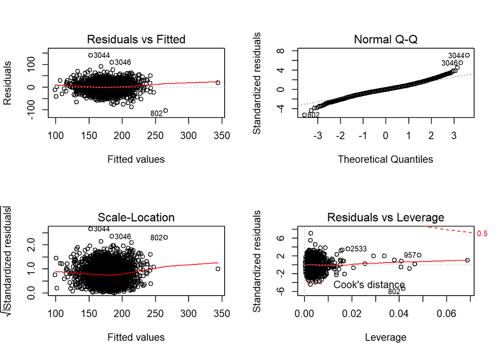

```r
par(mfrow = c(2, 2))
plot(fit_r2)
```

### 6. Examine Leverage & Influential points

#### 6.1 **Outliers in Y - Studentized Residuals**

We use internally studentized residuals to quantify the magnitude of residuals in standard deviation unit. As a rule of thumb, an observation with |r<sub>i</sub>| > 2.5 may be considered an outlier in Y.

The following points are extreme outliers in y with |r<sub>i</sub>| > 5.0:

```r
# add predictions & residuals for 7 predictor model to dataset
# df below used to examine state and county for outliers in y.
cancer_reg_pred_resid = cancer_reg %>%
  dplyr::select(
    state, county, target_death_rate, incidence_rate, median_age_male, pct_hs18_24, pct_bach_deg25_over, pct_private_coverage, pct_public_coverage_alone, pct_other_race, pct_married_households) %>%
  modelr::add_predictions(fit_r2, var = "pred_model_7") %>%
  modelr::add_residuals(fit_r2, var = "resid_model_7") %>%
  arrange(target_death_rate, incidence_rate)

# rstandard function gives the INTERNALLY studentized residuals
stu_res = rstandard(fit_r2)
# 68 points with student residuals > 2.5
stu_res[abs(stu_res) > 2.5]
```

```
##         2        12        15        20        21        23        24
## -3.302913 -2.944595 -2.793651 -2.552373 -2.924449 -2.692933 -3.879776
##        26        32        33        37        49        52        56
## -3.626371 -2.916625 -2.810990 -2.617649 -2.637638 -3.243006 -2.537397
##        65        68        81        84        90        91        95
## -3.446805 -2.671769 -2.668520 -3.825802 -3.358349 -2.662012 -2.587536
##        97       181       194       196       231       232       516
## -4.380481 -2.688962 -2.568263 -2.711789 -3.452689 -2.674541 -2.989074
##       542       802       831       899      1429      1558      2064
## -3.137305 -5.320612 -2.652789 -2.540816 -2.658073  2.626105  2.738653
##      2533      2575      2593      2669      2743      2766      2778
##  3.593141  2.513721  3.155232  2.539777  2.667944  3.372954  2.666621
##      2879      2889      2890      2892      2915      2958      2979
##  3.210251  2.970465  2.867645  2.880474  3.826957  2.757210  3.335931
##      2999      3001      3004      3012      3013      3016      3021
##  2.664019  3.386607  3.169338  2.740567  2.535051  2.937175  2.740020
##      3024      3029      3034      3036      3038      3039      3041
##  4.589266  3.879195  3.025954  2.911494  3.074778  2.997004  3.242610
##      3042      3043      3044      3045      3046
##  2.687599  2.789368  7.090297  2.545521  5.543707
```

```r
# 3 points with student residuals > 5
stu_res[abs(stu_res) > 5]
```

```
##       802      3044      3046
## -5.320612  7.090297  5.543707
```

```r
# test remove point 802: Williamsburg County, Virginia
# no substantial change in coefficients.
cancer_reg_remove =
  cancer_reg_tidy %>%
  filter(incidence_rate != 1014.2)

model_remove = lm(formula = target_death_rate ~ incidence_rate + median_age_male + pct_hs18_24 + pct_bach_deg25_over + pct_public_coverage_alone + pct_other_race + pct_married_households, data = cancer_reg_remove)

summary(model_remove)
```

```
##
## Call:
## lm(formula = target_death_rate ~ incidence_rate + median_age_male +
##     pct_hs18_24 + pct_bach_deg25_over + pct_public_coverage_alone +
##     pct_other_race + pct_married_households, data = cancer_reg_remove)
##
## Residuals:
##     Min      1Q  Median      3Q     Max
## -86.539 -11.213  -0.382  11.292 139.561
##
## Coefficients:
##                             Estimate Std. Error t value Pr(>|t|)
## (Intercept)               132.716769   6.671624  19.893  < 2e-16 ***
## incidence_rate              0.200206   0.006907  28.985  < 2e-16 ***
## median_age_male            -0.514613   0.074751  -6.884 7.02e-12 ***
## pct_hs18_24                 0.344285   0.044555   7.727 1.48e-14 ***
## pct_bach_deg25_over        -1.626686   0.090605 -17.954  < 2e-16 ***
## pct_public_coverage_alone   0.757424   0.087531   8.653  < 2e-16 ***
## pct_other_race             -1.043486   0.108964  -9.576  < 2e-16 ***
## pct_married_households     -0.514167   0.067558  -7.611 3.61e-14 ***
## ---
## Signif. codes:  0 '***' 0.001 '**' 0.01 '*' 0.05 '.' 0.1 ' ' 1
##
## Residual standard error: 19.68 on 3038 degrees of freedom
## Multiple R-squared:  0.4985, Adjusted R-squared:  0.4974
## F-statistic: 431.5 on 7 and 3038 DF,  p-value: < 2.2e-16
```

#### 6.2 **Outliers in X - Leverage Values**

To determine outliers in X, we use leverage values (diagonal elements h<sub>ii</sub> of the hat matrix) to measure how far each observation sits from the center of the X space. Observations with high leverage may have an influence on the fitted model’s estimated coefficients. Observations with a leverage value 0.2 < h<sub>ii</sub> < 0.5, will be considered moderate leverage observations. Examining the “hat” plot below, we do not observe any outliers in X.

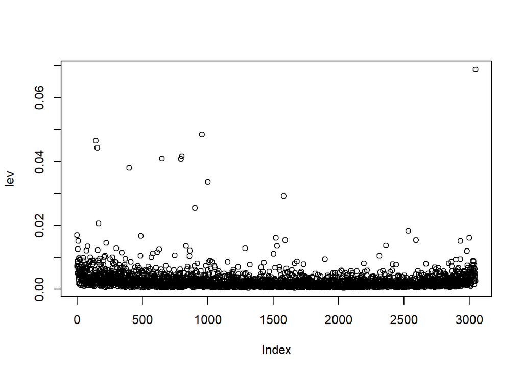

```r
# Obtain DFFITS, Cook's Distance, Hat diagonal elements.
influence_measures = influence.measures(fit_r2)

# plot of hat values and extract hat values above 0.2.
lev = hat(model.matrix(fit_r2))
plot(lev)
```

```r
# command returns all observations with leverage values above 0.2
cancer_reg_tidy[lev > 0.2,]
```

```
## # A tibble: 0 x 21
## # ... with 21 variables: target_death_rate <dbl>, incidence_rate <dbl>,
## #   med_income <dbl>, pop_est2015 <dbl>, study_per_cap <dbl>,
## #   median_age <dbl>, median_age_male <dbl>, avg_household_size <dbl>,
## #   pct_no_hs18_24 <dbl>, pct_hs18_24 <dbl>, pct_bach_deg18_24 <dbl>,
## #   pct_bach_deg25_over <dbl>, pct_unemployed16_over <dbl>,
## #   pct_public_coverage_alone <dbl>, pct_white <dbl>, pct_black <dbl>,
## #   pct_asian <dbl>, pct_other_race <dbl>, pct_married_households <dbl>,
## #   birth_rate <dbl>, pct_nonwhite <dbl>
```

#### 6.3 **Influential Points - Cook’s Distance**

After identifying the outliers in Y (points 802, 3044, 3046), we will use Cook’s distance measures to determine if they are influential. Applying **Cook’s distance** criteria, an observation can be influential if it has a high residual and high h<sub>ii</sub>. As a rule of thumb, a D<sub>i</sub> > 0.5 in R is of concern. Examination of the Cook’s distance reveals that none of the y-outliers 802 (red), 3044 (blue), or 3046 (green) met the criteria as influential points. As such, we will not take further actions to remove Y outliers from our dataset.

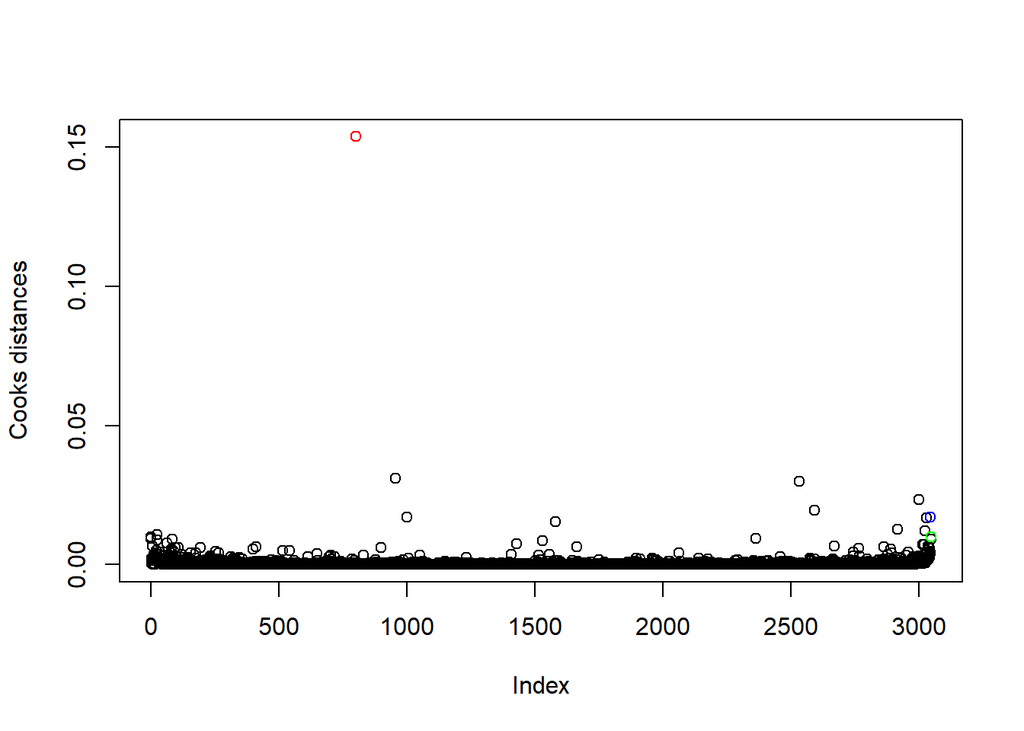

```r
# plot Cook's distance for fit_r2 7-predictor model
cook = cooks.distance(fit_r2)
plot(cook,ylab = "Cooks distances")
points(802,cook[802],col = 'red')
points(3044,cook[3044],col = 'blue')
points(3046,cook[3046],col = 'green')
```

### 7. N-Fold Cross Validation & Violin Plots

```r
set.seed(20)
# create training and testing sets, 100 fold cross-validation, 80/20 split
cv_cm = modelr::crossv_mc(data = cancer_reg_tidy, n = 100, test = 0.2, id = "id")

#
cv_cm = cv_cm %>%
  mutate(lm_auto = map(train, ~lm(target_death_rate ~ pct_bach_deg25_over + incidence_rate + pct_public_coverage_alone + pct_other_race + pct_white + pct_hs18_24 + median_age_male + birth_rate + pct_married_households + pct_unemployed16_over, data = .x)),
         lm_cp = map(train, ~lm(target_death_rate ~ incidence_rate + median_age_male + pct_hs18_24 + pct_bach_deg25_over + pct_unemployed16_over + pct_public_coverage_alone + pct_other_race + pct_married_households + birth_rate, data = .x)),
         lm_r2 = map(train, ~lm(target_death_rate ~ incidence_rate + median_age_male + pct_hs18_24 + pct_bach_deg25_over + pct_public_coverage_alone + pct_other_race + pct_married_households, data = .x))) %>%
  mutate(rmse_auto = map2_dbl(lm_auto, test, ~rmse(model = .x, data = .y)),
         rmse_cp = map2_dbl(lm_cp, test, ~rmse(model = .x, data = .y)),
         rmse_r2 = map2_dbl(lm_r2, test, ~rmse(model = .x, data = .y)))
```

```r
# experimental values for RMSE will vary each time we rerun code
cv_cm %>%
  dplyr::select(starts_with("rmse")) %>%
  gather(key = model, value = rmse) %>%
  group_by(model) %>%
  summarise(mean_rmse = mean(rmse),
            var_rmse = var(rmse))
```

```
## # A tibble: 3 x 3
##   model     mean_rmse var_rmse
##   <chr>         <dbl>    <dbl>
## 1 rmse_auto      19.6    0.758
## 2 rmse_cp        19.6    0.763
## 3 rmse_r2        19.7    0.738
```

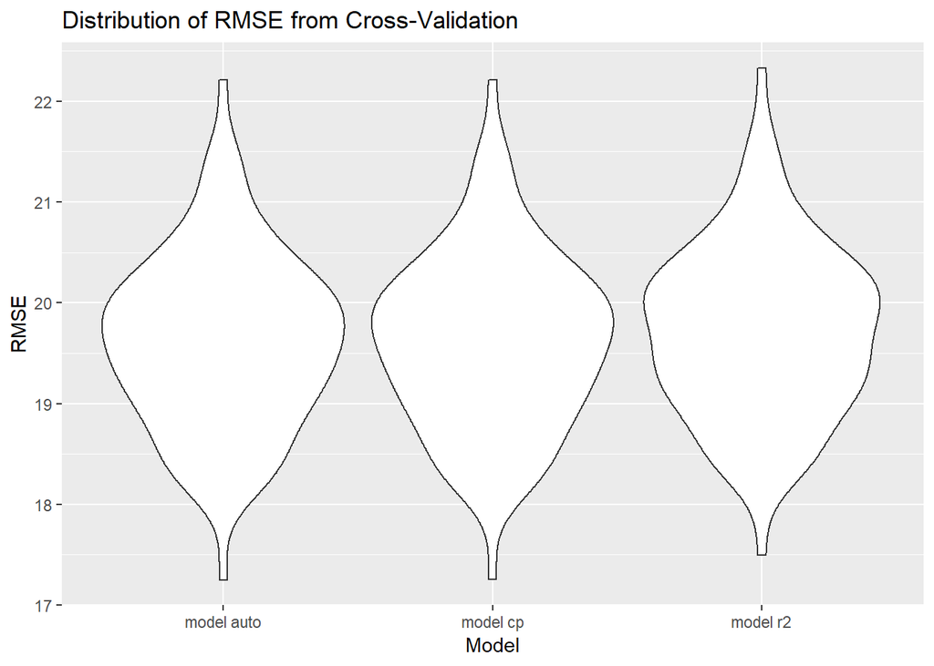

```r
# Violin Plots
cv_cm %>%
  dplyr::select(starts_with("rmse")) %>%
  gather(key = model, value = rmse) %>%
  mutate(
    model = str_replace(model, "rmse_", "model "),
    model = fct_reorder(model, rmse)) %>%
  ggplot(aes(x = model, y = rmse)) +
    geom_violin() +
  labs(title = "Distribution of RMSE from Cross-Validation",
    x = "Model",
    y = "RMSE")
```

### 8. K-Fold Cross validation

```r
model_10 = lm(formula = target_death_rate ~ pct_bach_deg25_over + incidence_rate + pct_public_coverage_alone + pct_other_race + pct_white + pct_hs18_24 + median_age_male + birth_rate + pct_married_households + pct_unemployed16_over, data = cancer_reg_tidy)

model_9 = lm(formula = target_death_rate ~ incidence_rate + median_age_male + pct_hs18_24 + pct_bach_deg25_over + pct_unemployed16_over + pct_public_coverage_alone + pct_other_race + pct_married_households + birth_rate, data = cancer_reg_tidy)

model_7 = lm(formula = target_death_rate ~ incidence_rate + median_age_male + pct_bach_deg25_over + pct_hs18_24 + pct_public_coverage_alone + pct_other_race + pct_married_households, data = cancer_reg_tidy)
```

### 8.1. 10-fold CV

```r
library(caret)
train_data_10 = caret::trainControl(method = "cv", number = 10)

# Fit the 4-variables model that we discussed in previous lectures
model_caret10_10 =
  caret::train(target_death_rate ~ pct_bach_deg25_over + incidence_rate + pct_public_coverage_alone + pct_other_race + pct_white + pct_hs18_24 + median_age_male + birth_rate + pct_married_households + pct_unemployed16_over,
    data = cancer_reg_tidy,
    trControl = train_data_10,
    method = 'lm',
    na.action = na.pass)

model_caret10_9 =
  caret::train(target_death_rate ~ incidence_rate + median_age_male + pct_hs18_24 + pct_bach_deg25_over + pct_unemployed16_over + pct_public_coverage_alone + pct_other_race + pct_married_households + birth_rate,
    data = cancer_reg_tidy,
    trControl = train_data_10,
    method = 'lm',
    na.action = na.pass)

model_caret10_7 =
  caret::train(target_death_rate ~ incidence_rate + median_age_male + pct_bach_deg25_over + pct_hs18_24 + pct_public_coverage_alone + pct_other_race + pct_married_households,
    data = cancer_reg_tidy,
    trControl = train_data_10,
    method = 'lm',
    na.action = na.pass)

model_caret10_10
```

```
## Linear Regression
##
## 3047 samples
##   10 predictor
##
## No pre-processing
## Resampling: Cross-Validated (10 fold)
## Summary of sample sizes: 2742, 2743, 2741, 2742, 2743, 2743, ...
## Resampling results:
##
##   RMSE      Rsquared   MAE
##   19.68269  0.4971362  14.65607
##
## Tuning parameter 'intercept' was held constant at a value of TRUE
```

```r
#  RMSE     Rsquared   MAE
#  19.7024  0.4938789  14.68475

model_caret10_9
```

```
## Linear Regression
##
## 3047 samples
##    9 predictor
##
## No pre-processing
## Resampling: Cross-Validated (10 fold)
## Summary of sample sizes: 2742, 2742, 2742, 2743, 2743, 2740, ...
## Resampling results:
##
##   RMSE      Rsquared   MAE
##   19.68522  0.4952884  14.66737
##
## Tuning parameter 'intercept' was held constant at a value of TRUE
```

```r
#  RMSE      Rsquared   MAE
#  19.68147  0.4967687  14.66503

model_caret10_7
```

```
## Linear Regression
##
## 3047 samples
##    7 predictor
##
## No pre-processing
## Resampling: Cross-Validated (10 fold)
## Summary of sample sizes: 2741, 2742, 2742, 2742, 2743, 2742, ...
## Resampling results:
##
##   RMSE      Rsquared   MAE
##   19.79656  0.4891366  14.84083
##
## Tuning parameter 'intercept' was held constant at a value of TRUE
```

```r
#  RMSE      Rsquared   MAE
#  19.79374  0.4900993  14.82677
```

### 8.2. 5-fold cv

```r
train_data_5 = caret::trainControl(method = "cv", number = 5)

# Fit the 4-variables model that we discussed in previous lectures
model_caret5_10 =
  caret::train(target_death_rate ~ pct_bach_deg25_over + incidence_rate + pct_public_coverage_alone + pct_other_race + pct_white + pct_hs18_24 + median_age_male + birth_rate + pct_married_households + pct_unemployed16_over,
    data = cancer_reg_tidy,
    trControl = train_data_5,
    method = 'lm',
    na.action = na.pass)

model_caret5_9 =
  caret::train(target_death_rate ~ incidence_rate + median_age_male + pct_hs18_24 + pct_bach_deg25_over + pct_unemployed16_over + pct_public_coverage_alone + pct_other_race + pct_married_households + birth_rate,
    data = cancer_reg_tidy,
    trControl = train_data_5,
    method = 'lm',
    na.action = na.pass)

model_caret5_7 =
  caret::train(target_death_rate ~ incidence_rate + median_age_male + pct_bach_deg25_over + pct_hs18_24 + pct_public_coverage_alone + pct_other_race + pct_married_households,
    data = cancer_reg_tidy,
    trControl = train_data_5,
    method = 'lm',
    na.action = na.pass)

model_caret5_10
```

```
## Linear Regression
##
## 3047 samples
##   10 predictor
##
## No pre-processing
## Resampling: Cross-Validated (5 fold)
## Summary of sample sizes: 2438, 2437, 2438, 2437, 2438
## Resampling results:
##
##   RMSE      Rsquared   MAE
##   19.76257  0.4932612  14.69665
##
## Tuning parameter 'intercept' was held constant at a value of TRUE
```

```r
#  RMSE      Rsquared   MAE
#  19.70115  0.4967758  14.65786

model_caret5_9
```

```
## Linear Regression
##
## 3047 samples
##    9 predictor
##
## No pre-processing
## Resampling: Cross-Validated (5 fold)
## Summary of sample sizes: 2438, 2439, 2437, 2437, 2437
## Resampling results:
##
##   RMSE      Rsquared   MAE
##   19.69091  0.4965753  14.66263
##
## Tuning parameter 'intercept' was held constant at a value of TRUE
```

```r
#  RMSE      Rsquared   MAE
#  19.69373  0.4956894  14.66347

model_caret5_7
```

```
## Linear Regression
##
## 3047 samples
##    7 predictor
##
## No pre-processing
## Resampling: Cross-Validated (5 fold)
## Summary of sample sizes: 2438, 2436, 2438, 2437, 2439
## Resampling results:
##
##   RMSE      Rsquared   MAE
##   19.78755  0.4917979  14.82262
##
## Tuning parameter 'intercept' was held constant at a value of TRUE
```

```r
#  RMSE      Rsquared   MAE
#  19.82486  0.4890669  14.84762
```

Since three models have similar performance in cross validation, based on ‘principle of parsimony’, we chose model with 7 predictors.

### 9. Ridge Regression

```r
grid = 10^seq(5,-2, length=100)
ridge_cancer =
  lm.ridge(target_death_rate ~ incidence_rate + median_age_male + pct_bach_deg25_over + pct_hs18_24 +
               pct_public_coverage_alone + pct_other_race + pct_married_households, data = cancer_reg_tidy, lambda = grid)
dim(coef(ridge_cancer))
```

```
## [1] 100   8
```

```r
#coef for 10^5
coef(ridge_cancer)[1,]
```

```
##                                      incidence_rate
##             176.751255509               0.006704046
##           median_age_male       pct_bach_deg25_over
##              -0.003929864              -0.071977113
##               pct_hs18_24 pct_public_coverage_alone
##               0.022967715               0.058400673
##            pct_other_race    pct_married_households
##              -0.043772906              -0.035548118
```

```r
# coeffcients for 10^-2
coef(ridge_cancer)[100,]
```

```
##                                      incidence_rate
##               134.8623726                 0.1933287
##           median_age_male       pct_bach_deg25_over
##                -0.5053064                -1.6346269
##               pct_hs18_24 pct_public_coverage_alone
##                 0.3504936                 0.7666369
##            pct_other_race    pct_married_households
##                -1.0573485                -0.5088586
```

```r
response =
  cancer_reg %>%
  dplyr::select(target_death_rate, incidence_rate, median_age_male, pct_bach_deg25_over, pct_hs18_24,
               pct_public_coverage_alone, pct_other_race, pct_married_households) %>%
#  drop_na() %>%
  dplyr::select(target_death_rate) %>%
  as.matrix()

predictors =
  cancer_reg %>%
  dplyr::select(target_death_rate, incidence_rate, median_age_male, pct_bach_deg25_over, pct_hs18_24,
               pct_public_coverage_alone, pct_other_race, pct_married_households) %>%
#  drop_na() %>%
  dplyr::select(-target_death_rate) %>%
  as.matrix()

ridge_cancer_1 = glmnet(predictors, response, alpha = 0, lambda = grid)
dim(coef(ridge_cancer_1))
```

```
## [1]   8 100
```

```r
ridge_cancer_1$lambda[50]
```

```
## [1] 34.30469
```

```r
coef(ridge_cancer_1)[,50]
```

```
##               (Intercept)            incidence_rate
##              153.82818170                0.09270319
##           median_age_male       pct_bach_deg25_over
##               -0.14152271               -0.82866145
##               pct_hs18_24 pct_public_coverage_alone
##                0.23892976                0.59102807
##            pct_other_race    pct_married_households
##               -0.56870531               -0.36531227
```

### 9.1 Ridge Cross Validation

Cross validation was used to obtain the smallest lambda

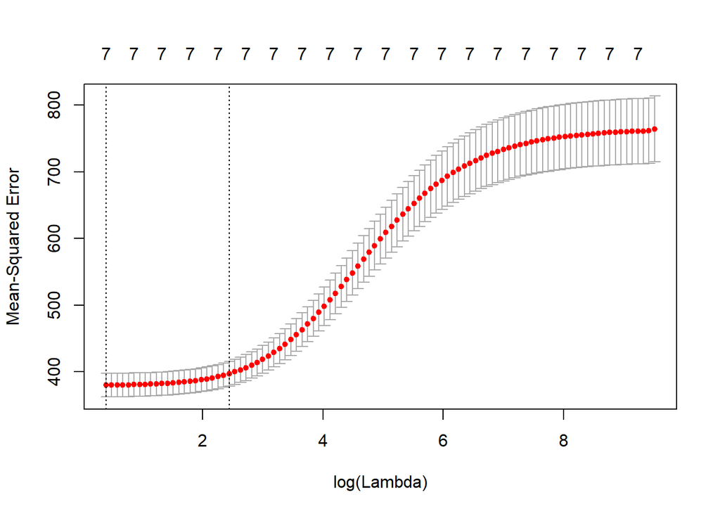

```r
set.seed(1)

cancer_train = sample(1:nrow(predictors),nrow(predictors)/2)

cancer_test = (-cancer_train)

response_test = response[cancer_test]


# Use build-in CV function; performs a 10-fold validation by default
# glmnet() generates it's own lambda sequence

set.seed(2)
cv_out = cv.glmnet(predictors[cancer_train,], response[cancer_train], alpha=0)
plot(cv_out)
```

```r
# cv.glmnet() object contains the mean cross-validation error (cvm),
# lambda min that gives the minimum cvm, etc.
cv_out
```

[output not shown]

[output cut: 207 more lines]

```r
best_lambda = cv_out$lambda.min
best_lambda
```

```
## [1] 1.48541
```

```r
# Re-fit the model with the min lambda value, look at the coeff and MSE
# Ridge regression using all observations and 'best' lambda
ridge_pred = glmnet(predictors, response, alpha = 0, lambda = best_lambda)

#Compare LS method and ridge
compare_ridge_ls = cbind(coef(model_7), coef(ridge_pred))
colnames(compare_ridge_ls) <- c("LS", "Ridge")
compare_ridge_ls
```

```
## 8 x 2 sparse Matrix of class "dgCMatrix"
##                                    LS       Ridge
## (Intercept)               134.8623510 135.4829403
## incidence_rate              0.1933293   0.1844144
## median_age_male            -0.5053091  -0.4642871
## pct_bach_deg25_over        -1.6346329  -1.5460046
## pct_hs18_24                 0.3504938   0.3470415
## pct_public_coverage_alone   0.7666357   0.7788482
## pct_other_race             -1.0573507  -1.0224673
## pct_married_households     -0.5088592  -0.5012110
```

### 10. Final Model

Final model: `lm(formula = target_death_rate ~ incidence_rate + median_age_male + pct_hs18_24 + pct_bach_deg25_over + pct_public_coverage_alone + pct_other_race + pct_married_households, data = cancer_reg_tidy)`

```r
fit_final = lm(formula = target_death_rate ~ incidence_rate + median_age_male + pct_hs18_24 + pct_bach_deg25_over + pct_public_coverage_alone + pct_other_race + pct_married_households, data = cancer_reg_tidy)

# Final Model Coefficients
fit_final %>% broom::tidy(conf.int = TRUE) %>%
  dplyr::select(term, estimate, conf.low, conf.high, std.error, p.value) %>%
  rename(
    "beta1 estimates" = estimate,
    "95% CI lower" = conf.low,
    "95% CI upper" = conf.high) %>%
  knitr::kable(digits = 3)
```

| term | beta1 estimates | 95% CI lower | 95% CI upper | std.error | p.value |
| --- | --- | --- | --- | --- | --- |
| (Intercept) | 134.862 | 121.746 | 147.979 | 6.690 | 0 |
| incidence_rate | 0.193 | 0.180 | 0.207 | 0.007 | 0 |
| median_age_male | -0.505 | -0.653 | -0.358 | 0.075 | 0 |
| pct_hs18_24 | 0.350 | 0.263 | 0.438 | 0.045 | 0 |
| pct_bach_deg25_over | -1.635 | -1.813 | -1.456 | 0.091 | 0 |
| pct_public_coverage_alone | 0.767 | 0.594 | 0.939 | 0.088 | 0 |
| pct_other_race | -1.057 | -1.272 | -0.843 | 0.109 | 0 |
| pct_married_households | -0.509 | -0.642 | -0.376 | 0.068 | 0 |

### IGNORE

```r
poverty_fit = lm(poverty_percent ~ pct_public_coverage_alone, data = cancer_reg)
summary(poverty_fit)
```

```
##
## Call:
## lm(formula = poverty_percent ~ pct_public_coverage_alone, data = cancer_reg)
##
## Residuals:
##      Min       1Q   Median       3Q      Max
## -15.5872  -2.3721  -0.4298   1.7310  24.8908
##
## Coefficients:
##                           Estimate Std. Error t value Pr(>|t|)
## (Intercept)                0.76809    0.23083   3.328 0.000886 ***
## pct_public_coverage_alone  0.83732    0.01143  73.230  < 2e-16 ***
## ---
## Signif. codes:  0 '***' 0.001 '**' 0.01 '*' 0.05 '.' 0.1 ' ' 1
##
## Residual standard error: 3.858 on 3045 degrees of freedom
## Multiple R-squared:  0.6378, Adjusted R-squared:  0.6377
## F-statistic:  5363 on 1 and 3045 DF,  p-value: < 2.2e-16
```

```r
education_fit = lm(pct_hs18_24 ~ pct_bach_deg25_over, data = cancer_reg)
summary(education_fit)
```

```
##
## Call:
## lm(formula = pct_hs18_24 ~ pct_bach_deg25_over, data = cancer_reg)
##
## Residuals:
##     Min      1Q  Median      3Q     Max
## -30.813  -5.055  -0.080   4.761  44.791
##
## Coefficients:
##                     Estimate Std. Error t value Pr(>|t|)
## (Intercept)         44.04017    0.39938  110.27   <2e-16 ***
## pct_bach_deg25_over -0.68048    0.02786  -24.43   <2e-16 ***
## ---
## Signif. codes:  0 '***' 0.001 '**' 0.01 '*' 0.05 '.' 0.1 ' ' 1
##
## Residual standard error: 8.295 on 3045 degrees of freedom
## Multiple R-squared:  0.1638, Adjusted R-squared:  0.1636
## F-statistic: 596.6 on 1 and 3045 DF,  p-value: < 2.2e-16
```

```r
insurance_fit = lm(pct_private_coverage ~ pct_public_coverage_alone, data = cancer_reg)
summary(insurance_fit)
```

```
##
## Call:
## lm(formula = pct_private_coverage ~ pct_public_coverage_alone,
##     data = cancer_reg)
##
## Residuals:
##      Min       1Q   Median       3Q      Max
## -30.8652  -2.6351   0.6456   3.4318  13.7187
##
## Coefficients:
##                           Estimate Std. Error t value Pr(>|t|)
## (Intercept)               94.05294    0.29517   318.6   <2e-16 ***
## pct_public_coverage_alone -1.54355    0.01462  -105.6   <2e-16 ***
## ---
## Signif. codes:  0 '***' 0.001 '**' 0.01 '*' 0.05 '.' 0.1 ' ' 1
##
## Residual standard error: 4.933 on 3045 degrees of freedom
## Multiple R-squared:  0.7854, Adjusted R-squared:  0.7853
## F-statistic: 1.114e+04 on 1 and 3045 DF,  p-value: < 2.2e-16
```